# ReneWind

## Model Building with Oversampled data

```python
!pip install imblearn
```

```python
# Synthetic Minority Over Sampling Technique
from imblearn.over_sampling import SMOTE

sm = SMOTE(sampling_strategy=1, k_neighbors=5, random_state=1)
X_train_over, y_train_over = sm.fit_resample(X_train, y_train)
```

```python
print("Before UpSampling, counts of label 'Yes': {}".format(sum(y_train==1)))
print("Before UpSampling, counts of label 'No': {} \n".format(sum(y_train==0)))

print("After UpSampling, counts of label 'Yes': {}".format(sum(y_train_over==1)))
print("After UpSampling, counts of label 'No': {} \n".format(sum(y_train_over==0)))


print('After UpSampling, the shape of train_X: {}'.format(X_train_over.shape))
print('After UpSampling, the shape of train_y: {} \n'.format(y_train_over.shape))
```

```
Before UpSampling, counts of label 'Yes': 1543
Before UpSampling, counts of label 'No': 26457

After UpSampling, counts of label 'Yes': 26457
After UpSampling, counts of label 'No': 26457

After UpSampling, the shape of train_X: (52914, 40)
After UpSampling, the shape of train_y: (52914,)
```

### LOGESTIC REGRESSION-Oversampled

```python
log_reg_over = LogisticRegression(random_state = 1)

# Training the basic logistic regression model with the training set
log_reg_over.fit(X_train_over,y_train_over)
```

```
LogisticRegression(random_state=1)
```

**Let's evaluate the model performance by using KFold and cross_val_score**

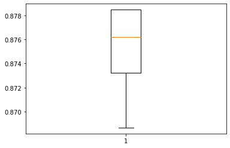

```python
scoring='recall'
kfold=StratifiedKFold(n_splits=5,shuffle=True,random_state=1)     #Setting number of splits equal to 5
cv_result_over=cross_val_score(estimator=log_reg_over, X=X_train_over, y=y_train_over, scoring=scoring, cv=kfold)
#Plotting boxplots for CV scores of model defined above
plt.boxplot(cv_result_over)
plt.show()
```

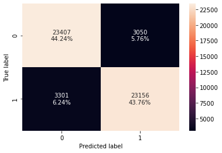

```python
confusion_matrix_sklearn(log_reg_over, X_train_over,y_train_over)
```

```python
log_reg_over_score =model_performance_classification_sklearn(
    log_reg_over, X_train_over, y_train_over
)

print("Training performance:")
log_reg_over_score
```

```
Training performance:
```

|  | Accuracy | Recall | Precision | F1 | Minimum_Vs_Model_cost |
| --- | --- | --- | --- | --- | --- |
| 0 | 0.880 | 0.875 | 0.884 | 0.879 | 0.802 |

```python
# Calculating different metrics on validation set
log_reg_over_val_perf = model_performance_classification_sklearn(
    log_reg_over, X_val, y_val
)
print("validation performance:")
log_reg_over_val_perf
```

```
validation performance:
```

|  | Accuracy | Recall | Precision | F1 | Minimum_Vs_Model_cost |
| --- | --- | --- | --- | --- | --- |
| 0 | 0.885 | 0.865 | 0.302 | 0.448 | 0.529 |

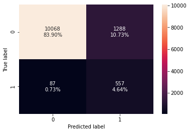

```python
# creating confusion matrix
confusion_matrix_sklearn(log_reg_over, X_val, y_val)
```

Performance on the training set in not bad but Precision and F1 scores on the validation set have been dropped. it may because of overfitting

### DecisionTreeClassifier-Oversampled

```python
DecisionTreeClassifier_OVER = DecisionTreeClassifier(
    criterion="gini", class_weight={0: 0.14, 1: 0.85}, random_state=1
)
DecisionTreeClassifier_OVER.fit(X_train_over,y_train_over)
```

```
DecisionTreeClassifier(class_weight={0: 0.14, 1: 0.85}, random_state=1)
```

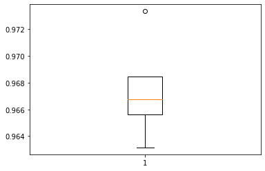

```python
scoring='recall'
kfold=StratifiedKFold(n_splits=5,shuffle=True,random_state=1) #Setting number of splits equal to 5
cv_result_over=cross_val_score(estimator=DecisionTreeClassifier_OVER,
                               X=X_train_over, y=y_train_over, scoring=scoring, cv=kfold)
#Plotting boxplots for CV scores of model defined above
plt.boxplot(cv_result_over)
plt.show()
```

Performance on training set varies between 0.963 to 0.968 recall. which is an improvement from the initial model(without oversampling)

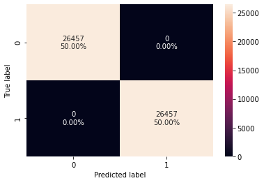

```python
confusion_matrix_sklearn(DecisionTreeClassifier_OVER, X_train_over, y_train_over)
```

```python
DecisionTree_OVER_SCORE =model_performance_classification_sklearn(
    DecisionTreeClassifier_OVER, X_train_over, y_train_over
)

print("Training performance:")
DecisionTree_OVER_SCORE
```

```
Training performance:
```

|  | Accuracy | Recall | Precision | F1 | Minimum_Vs_Model_cost |
| --- | --- | --- | --- | --- | --- |
| 0 | 1.000 | 1.000 | 1.000 | 1.000 | 1.000 |

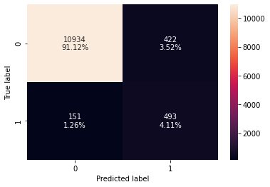

```python
confusion_matrix_sklearn(DecisionTreeClassifier_OVER, X_val, y_val)
```

```python
# Calculating different metrics on validation set
DecisionTree_OVER_val_perf = model_performance_classification_sklearn(
    DecisionTreeClassifier_OVER, X_val, y_val
)
print("validation performance:")
DecisionTree_OVER_val_perf
```

```
validation performance:
```

|  | Accuracy | Recall | Precision | F1 | Minimum_Vs_Model_cost |
| --- | --- | --- | --- | --- | --- |
| 0 | 0.952 | 0.766 | 0.539 | 0.632 | 0.621 |

Performance on the training set improved but the model is not able to replicate the same for the validation set.

Model is overfitting.

### Random forest-Oversampled

```python
rf_estimator_over = RandomForestClassifier(random_state=1)
rf_estimator_over.fit(X_train_over, y_train_over)
```

```
RandomForestClassifier(random_state=1)
```

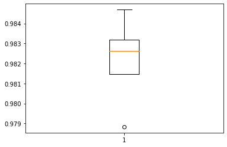

```python
scoring='recall'
kfold=StratifiedKFold(n_splits=5,shuffle=True,random_state=1) #Setting number of splits equal to 5
cv_result_over=cross_val_score(estimator=rf_estimator_over, X=X_train_over, y=y_train_over, scoring=scoring, cv=kfold)
#Plotting boxplots for CV scores of model defined above
plt.boxplot(cv_result_over)
plt.show()
```

Performance on training set varies between 0.981 to 0.985 recall.

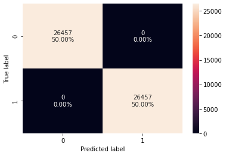

```python
confusion_matrix_sklearn(rf_estimator_over, X_train_over, y_train_over)
```

```python
rf_estimator_over_SCORE =model_performance_classification_sklearn(
    rf_estimator_over, X_train_over, y_train_over
)

print("Training performance:")
rf_estimator_over_SCORE
```

```
Training performance:
```

|  | Accuracy | Recall | Precision | F1 | Minimum_Vs_Model_cost |
| --- | --- | --- | --- | --- | --- |
| 0 | 1.000 | 1.000 | 1.000 | 1.000 | 1.000 |

- Performance on training set is too good lets check it on validation data.

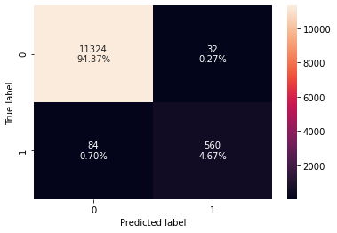

```python
confusion_matrix_sklearn(rf_estimator_over, X_val, y_val)# confusion_matrix on validation set
```

```python
# Calculating different metrics on validation set
rf_estimator_over_val_SCORE =model_performance_classification_sklearn(
    rf_estimator_over,  X_val, y_val
)

print("Training performance:")
rf_estimator_over_val_SCORE
```

```
Training performance:
```

|  | Accuracy | Recall | Precision | F1 | Minimum_Vs_Model_cost |
| --- | --- | --- | --- | --- | --- |
| 0 | 0.990 | 0.870 | 0.946 | 0.906 | 0.810 |

- the model has given a generalized performance on training and validation set.

### Bagging_Classifier_Oversampled

```python
bagging_classifier_over = BaggingClassifier(random_state=1)
bagging_classifier_over.fit(X_train_over, y_train_over)
```

```
BaggingClassifier(random_state=1)
```

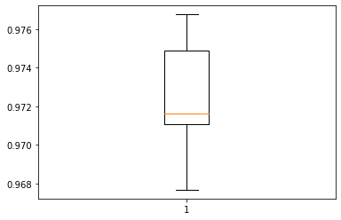

```python
scoring='recall'
kfold=StratifiedKFold(n_splits=5,shuffle=True,random_state=1) #Setting number of splits equal to 5
cv_result_over=cross_val_score(estimator=bagging_classifier_over, X=X_train_over, y=y_train_over, scoring=scoring, cv=kfold)
#Plotting boxplots for CV scores of model defined above
plt.boxplot(cv_result_over)
plt.show()
```

Performance on training set varies between 0.96 to 0.97 recall.

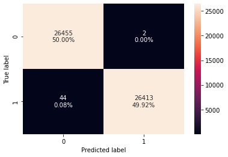

```python
confusion_matrix_sklearn(bagging_classifier_over, X_train_over, y_train_over)
```

```python
bagging_classifier_over_SCORE =model_performance_classification_sklearn(
    bagging_classifier_over, X_train_over, y_train_over
)

print("Training performance:")
bagging_classifier_over_SCORE
```

```
Training performance:
```

|  | Accuracy | Recall | Precision | F1 | Minimum_Vs_Model_cost |
| --- | --- | --- | --- | --- | --- |
| 0 | 0.999 | 0.998 | 1.000 | 0.999 | 0.997 |

Performance on training set is good lets check it on validation data.

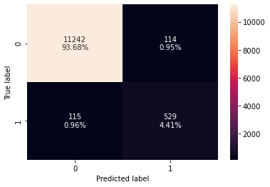

```python
confusion_matrix_sklearn(bagging_classifier_over, X_val, y_val)# confusion_matrix on validation set
```

```python
bagging_val_over_SCORE =model_performance_classification_sklearn(
    bagging_classifier_over, X_val, y_val
)

print("Training performance:")
bagging_val_over_SCORE
```

```
Training performance:
```

|  | Accuracy | Recall | Precision | F1 | Minimum_Vs_Model_cost |
| --- | --- | --- | --- | --- | --- |
| 0 | 0.981 | 0.821 | 0.823 | 0.822 | 0.737 |

model has given a generalized performance on training and validation set.

### AdaBoostClassifier_Oversampled

```python
ab_classifier_OVER = AdaBoostClassifier(random_state=1)
ab_classifier_OVER.fit(X_train_over, y_train_over)
```

```
AdaBoostClassifier(random_state=1)
```

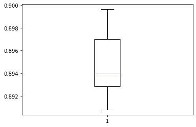

```python
scoring='recall'
kfold=StratifiedKFold(n_splits=5,shuffle=True,random_state=1) #Setting number of splits equal to 5
cv_result_over=cross_val_score(estimator=ab_classifier_OVER, X=X_train_over, y=y_train_over, scoring=scoring, cv=kfold)
#Plotting boxplots for CV scores of model defined above
plt.boxplot(cv_result_over)
plt.show()
```

Performance on training set varies between 0.891 to 0.899 recall.

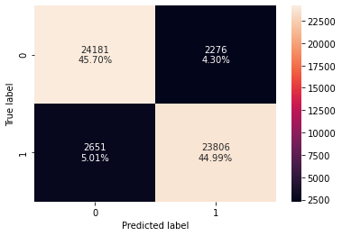

```python
confusion_matrix_sklearn(ab_classifier_OVER, X_train_over, y_train_over)
```

```python
ab_classifier_OVER_SCORE =model_performance_classification_sklearn(
    ab_classifier_OVER, X_train_over, y_train_over
)

print("Training performance:")
ab_classifier_OVER_SCORE
```

```
Training performance:
```

|  | Accuracy | Recall | Precision | F1 | Minimum_Vs_Model_cost |
| --- | --- | --- | --- | --- | --- |
| 0 | 0.907 | 0.900 | 0.913 | 0.906 | 0.836 |

model performance looks good. lets check it on validation data

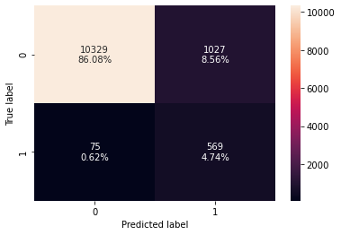

```python
confusion_matrix_sklearn(ab_classifier_OVER, X_val, y_val)# confusion_matrix on validation set
```

```python
ab_val_OVER_SCORE =model_performance_classification_sklearn(
    ab_classifier_OVER,X_val, y_val
)

print("Training performance:")
ab_val_OVER_SCORE
```

```
Training performance:
```

|  | Accuracy | Recall | Precision | F1 | Minimum_Vs_Model_cost |
| --- | --- | --- | --- | --- | --- |
| 0 | 0.908 | 0.884 | 0.357 | 0.508 | 0.579 |

scores of Accuracy and Recall are good but Precision and F1 scores dropped too much data is overfitting

### Gradient Boosting Classifier_Oversampled

```python
gb_classifier_over = GradientBoostingClassifier(random_state=1)
gb_classifier_over.fit(X_train_over, y_train_over)
```

```
GradientBoostingClassifier(random_state=1)
```

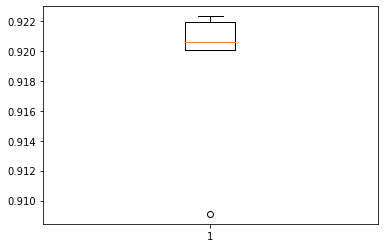

```python
scoring='recall'
kfold=StratifiedKFold(n_splits=5,shuffle=True,random_state=1) #Setting number of splits equal to 5
cv_result_over=cross_val_score(estimator=gb_classifier_over, X=X_train_over, y=y_train_over, scoring=scoring, cv=kfold)
#Plotting boxplots for CV scores of model defined above
plt.boxplot(cv_result_over)
plt.show()
```

Performance on training set varies between 0.920 to 0.922 recall.

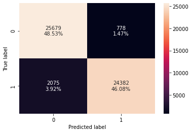

```python
confusion_matrix_sklearn(gb_classifier_over, X_train_over, y_train_over)
```

```python
gb_classifier_over_SCORE =model_performance_classification_sklearn(
    gb_classifier_over, X_train_over, y_train_over
)

print("Training performance:")
gb_classifier_over_SCORE
```

```
Training performance:
```

|  | Accuracy | Recall | Precision | F1 | Minimum_Vs_Model_cost |
| --- | --- | --- | --- | --- | --- |
| 0 | 0.946 | 0.922 | 0.969 | 0.945 | 0.877 |

Performance on the training set is good lets check validation data

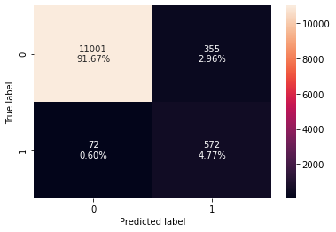

```python
confusion_matrix_sklearn(gb_classifier_over, X_val, y_val)# confusion_matrix on validation set
```

```python
gb_classifier_val_over_SCORE =model_performance_classification_sklearn(
    gb_classifier_over,X_val, y_val
)

print("Training performance:")
gb_classifier_val_over_SCORE
```

```
Training performance:
```

|  | Accuracy | Recall | Precision | F1 | Minimum_Vs_Model_cost |
| --- | --- | --- | --- | --- | --- |
| 0 | 0.964 | 0.888 | 0.617 | 0.728 | 0.730 |

Accuracy score improved but other scores dropped. data is overfitting

### XGBoost Classifier_Oversampled

```python
xgb_classifier_over = XGBClassifier(random_state=1,eval_metric='logloss')
xgb_classifier_over.fit(X_train_over, y_train_over)
```

```
XGBClassifier(base_score=0.5, booster='gbtree', colsample_bylevel=1,
              colsample_bynode=1, colsample_bytree=1, eval_metric='logloss',
              gamma=0, gpu_id=-1, importance_type='gain',
              interaction_constraints='', learning_rate=0.300000012,
              max_delta_step=0, max_depth=6, min_child_weight=1, missing=nan,
              monotone_constraints='()', n_estimators=100, n_jobs=8,
              num_parallel_tree=1, random_state=1, reg_alpha=0, reg_lambda=1,
              scale_pos_weight=1, subsample=1, tree_method='exact',
              validate_parameters=1, verbosity=None)
```

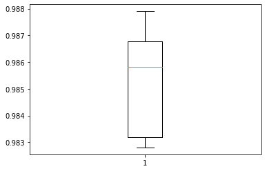

```python
scoring='recall'
kfold=StratifiedKFold(n_splits=5,shuffle=True,random_state=1) #Setting number of splits equal to 5
cv_result_over=cross_val_score(estimator=xgb_classifier_over, X=X_train_over, y=y_train_over, scoring=scoring, cv=kfold)
#Plotting boxplots for CV scores of model defined above
plt.boxplot(cv_result_over)
plt.show();
```

Performance on training set varies between 0.981 to 0.987 recall.

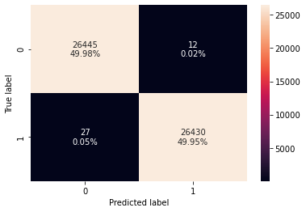

```python
confusion_matrix_sklearn(xgb_classifier_over, X_train_over, y_train_over)
```

```python
xgb_classifier_over_SCORE =model_performance_classification_sklearn(
   xgb_classifier_over, X_train_over, y_train_over
)

print("Training performance:")
xgb_classifier_over_SCORE
```

```
Training performance:
```

|  | Accuracy | Recall | Precision | F1 | Minimum_Vs_Model_cost |
| --- | --- | --- | --- | --- | --- |
| 0 | 0.999 | 0.999 | 1.000 | 0.999 | 0.998 |

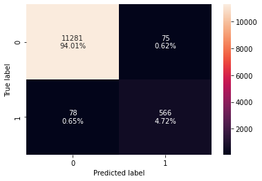

```python
#check the peformance on the validation data
confusion_matrix_sklearn(xgb_classifier_over, X_val, y_val)
```

```python
xgb_classifier_val_over_SCORE =model_performance_classification_sklearn(
   xgb_classifier_over, X_val, y_val
)

print("Training performance:")
xgb_classifier_val_over_SCORE
```

```
Training performance:
```

|  | Accuracy | Recall | Precision | F1 | Minimum_Vs_Model_cost |
| --- | --- | --- | --- | --- | --- |
| 0 | 0.987 | 0.879 | 0.883 | 0.881 | 0.806 |

I think performance on the validation is acceptable

## Model Building with Undersampled data

```python
# Random undersampler for under sampling the data
from imblearn.under_sampling import RandomUnderSampler
rus = RandomUnderSampler(random_state=1, sampling_strategy=1)
X_train_un, y_train_un = rus.fit_resample(X_train, y_train)
```

```python
print("Before Under Sampling, counts of label 'Yes': {}".format(sum(y_train==1)))
print("Before Under Sampling, counts of label 'No': {} \n".format(sum(y_train==0)))

print("After Under Sampling, counts of label 'Yes': {}".format(sum(y_train_un==1)))
print("After Under Sampling, counts of label 'No': {} \n".format(sum(y_train_un==0)))

print('After Under Sampling, the shape of train_X: {}'.format(X_train_un.shape))
print('After Under Sampling, the shape of train_y: {} \n'.format(y_train_un.shape))
```

```
Before Under Sampling, counts of label 'Yes': 1543
Before Under Sampling, counts of label 'No': 26457

After Under Sampling, counts of label 'Yes': 1543
After Under Sampling, counts of label 'No': 1543

After Under Sampling, the shape of train_X: (3086, 40)
After Under Sampling, the shape of train_y: (3086,)
```

### LogisticRegression-Undersampled

```python
log_reg_under = LogisticRegression(random_state = 1)
log_reg_under.fit(X_train_un,y_train_un )
```

```
LogisticRegression(random_state=1)
```

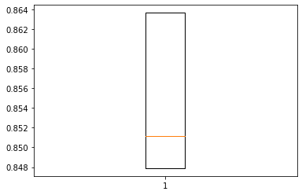

```python
scoring='recall'
kfold=StratifiedKFold(n_splits=5,shuffle=True,random_state=1)     #Setting number of splits equal to 5
cv_result_under=cross_val_score(estimator=log_reg_under, X=X_train_un, y=y_train_un, scoring=scoring, cv=kfold)
#Plotting boxplots for CV scores of model defined above
plt.boxplot(cv_result_under)
plt.show()
```

Performance on training set varies between 0.84 to 0.86 recall. which is an improvement from the initial model(without undersampling)

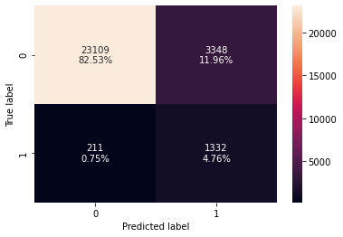

```python
confusion_matrix_sklearn(log_reg_under, X_train, y_train)
```

```python
log_reg_under_score =model_performance_classification_sklearn(
    log_reg_under, X_train, y_train
)

print("Training performance:")
log_reg_under_score
```

```
Training performance:
```

|  | Accuracy | Recall | Precision | F1 | Minimum_Vs_Model_cost |
| --- | --- | --- | --- | --- | --- |
| 0 | 0.873 | 0.863 | 0.285 | 0.428 | 0.513 |

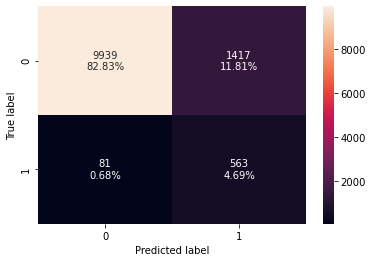

```python
confusion_matrix_sklearn(log_reg_under, X_val, y_val)
```

```python
log_reg_val_under_score =model_performance_classification_sklearn(
    log_reg_under,X_val, y_val
)

print("Training performance:")
log_reg_val_under_score
```

```
Training performance:
```

|  | Accuracy | Recall | Precision | F1 | Minimum_Vs_Model_cost |
| --- | --- | --- | --- | --- | --- |
| 0 | 0.875 | 0.874 | 0.284 | 0.429 | 0.515 |

The model is giving a generalized performance.

### DecisionTree-Undersampled

```python
DecisionTree_under = DecisionTreeClassifier(random_state = 1)
DecisionTree_under.fit(X_train_un,y_train_un )
```

```
DecisionTreeClassifier(random_state=1)
```

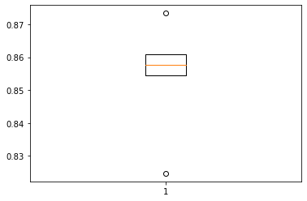

```python
scoring='recall'
kfold=StratifiedKFold(n_splits=5,shuffle=True,random_state=1)     #Setting number of splits equal to 5
cv_result_under=cross_val_score(estimator=DecisionTree_under, X=X_train_un, y=y_train_un, scoring=scoring, cv=kfold)
#Plotting boxplots for CV scores of model defined above
plt.boxplot(cv_result_under)
plt.show()
```

Performance on training set varies between 0.85 to 0.86 recall.

```python
confusion_matrix_sklearn(DecisionTree_under,X_train_un,y_train_un)
```

[output not shown]

```python
DecisionTree_under_score =model_performance_classification_sklearn(
    DecisionTree_under, X_train_un,y_train_un
)

print("Training performance:")
DecisionTree_under_score
```

```
Training performance:
```

|  | Accuracy | Recall | Precision | F1 | Minimum_Vs_Model_cost |
| --- | --- | --- | --- | --- | --- |
| 0 | 1.000 | 1.000 | 1.000 | 1.000 | 1.000 |

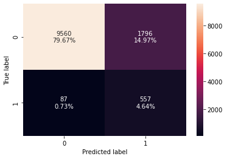

```python
confusion_matrix_sklearn(DecisionTree_under,X_val,y_val)
```

```python
DecisionTree_val_under_score =model_performance_classification_sklearn(
    DecisionTree_under, X_val,y_val
)

print("Training performance:")
DecisionTree_val_under_score
```

```
Training performance:
```

|  | Accuracy | Recall | Precision | F1 | Minimum_Vs_Model_cost |
| --- | --- | --- | --- | --- | --- |
| 0 | 0.843 | 0.865 | 0.237 | 0.372 | 0.464 |

data is obviously overfitting

### RandomForest-Undersampled

```python
rf_estimator_under= RandomForestClassifier(random_state=1)
rf_estimator_under.fit(X_train_un,y_train_un )
```

```
RandomForestClassifier(random_state=1)
```

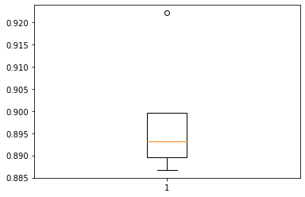

```python
scoring='recall'
kfold=StratifiedKFold(n_splits=5,shuffle=True,random_state=1)     #Setting number of splits equal to 5
cv_result_under=cross_val_score(estimator=rf_estimator_under, X=X_train_un, y=y_train_un, scoring=scoring, cv=kfold)
#Plotting boxplots for CV scores of model defined above
plt.boxplot(cv_result_under)
plt.show()
```

Performance on training set varies between 0.88 to 0.90 recall.

```python
confusion_matrix_sklearn(rf_estimator_under,X_train_un,y_train_un)
```

[output not shown]

```python
rf_estimator_under_score =model_performance_classification_sklearn(
   rf_estimator_under, X_train_un,y_train_un
)

print("Training performance:")
rf_estimator_under_score
```

```
Training performance:
```

|  | Accuracy | Recall | Precision | F1 | Minimum_Vs_Model_cost |
| --- | --- | --- | --- | --- | --- |
| 0 | 1.000 | 1.000 | 1.000 | 1.000 | 1.000 |

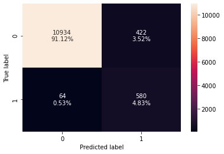

```python
confusion_matrix_sklearn(rf_estimator_under, X_val,y_val)
```

```python
rf_estimator_val_under_score =model_performance_classification_sklearn(
   rf_estimator_under, X_val,y_val
)

print("Training performance:")
rf_estimator_val_under_score
```

```
Training performance:
```

|  | Accuracy | Recall | Precision | F1 | Minimum_Vs_Model_cost |
| --- | --- | --- | --- | --- | --- |
| 0 | 0.960 | 0.901 | 0.579 | 0.705 | 0.723 |

Accuracy and Recall scores are good but Precision and F1 dramatically dropped

### BaggingClassifier-Undersampled

```python
bagging_classifier_under = BaggingClassifier(random_state=1)
bagging_classifier_under.fit(X_train_un,y_train_un)
```

```
BaggingClassifier(random_state=1)
```

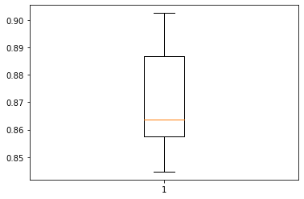

```python
scoring='recall'
kfold=StratifiedKFold(n_splits=5,shuffle=True,random_state=1) #Setting number of splits equal to 5
cv_result_under=cross_val_score(estimator=bagging_classifier_under, X=X_train_un, y=y_train_un, scoring=scoring, cv=kfold)
#Plotting boxplots for CV scores of model defined above
plt.boxplot(cv_result_under)
plt.show()
```

Performance on training set varies between 0.84 to 0.90 recall.

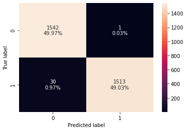

```python
confusion_matrix_sklearn(bagging_classifier_under,X_train_un,y_train_un)
```

```python
bagging_classifier_under_score =model_performance_classification_sklearn(
   bagging_classifier_under, X_train_un,y_train_un
)

print("Training performance:")
bagging_classifier_under_score
```

```
Training performance:
```

|  | Accuracy | Recall | Precision | F1 | Minimum_Vs_Model_cost |
| --- | --- | --- | --- | --- | --- |
| 0 | 0.990 | 0.981 | 0.999 | 0.990 | 0.968 |

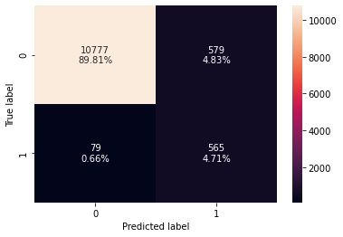

```python
confusion_matrix_sklearn(bagging_classifier_under,X_val,y_val)
```

```python
bagging_classifier_val_under_score =model_performance_classification_sklearn(
   bagging_classifier_under, X_val,y_val
)

print("Training performance:")
bagging_classifier_val_under_score
```

```
Training performance:
```

|  | Accuracy | Recall | Precision | F1 | Minimum_Vs_Model_cost |
| --- | --- | --- | --- | --- | --- |
| 0 | 0.945 | 0.877 | 0.494 | 0.632 | 0.665 |

Performance on the training set improved but the model is not able to replicate the same for the validation set.

Model is overfitting.

### AdaBoostClassifier-Undersampled

```python
ab_classifier_under = AdaBoostClassifier(random_state=1)
ab_classifier_under.fit(X_train_un,y_train_un)
```

```
AdaBoostClassifier(random_state=1)
```

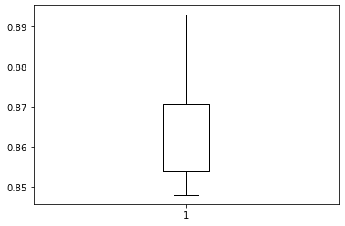

```python
scoring='recall'
kfold=StratifiedKFold(n_splits=5,shuffle=True,random_state=1)     #Setting number of splits equal to 5
cv_result_under=cross_val_score(estimator=ab_classifier_under, X=X_train_un, y=y_train_un, scoring=scoring, cv=kfold)
#Plotting boxplots for CV scores of model defined above
plt.boxplot(cv_result_under)
plt.show()
```

Performance on training set varies between 0.84 to 0.89 recall.

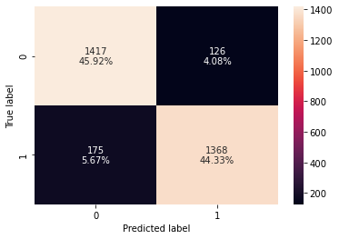

```python
confusion_matrix_sklearn(ab_classifier_under,X_train_un,y_train_un)
```

```python
ab_classifier_under_score =model_performance_classification_sklearn(
   ab_classifier_under, X_train_un,y_train_un
)

print("Training performance:")
ab_classifier_under_score
```

```
Training performance:
```

|  | Accuracy | Recall | Precision | F1 | Minimum_Vs_Model_cost |
| --- | --- | --- | --- | --- | --- |
| 0 | 0.902 | 0.887 | 0.916 | 0.901 | 0.822 |

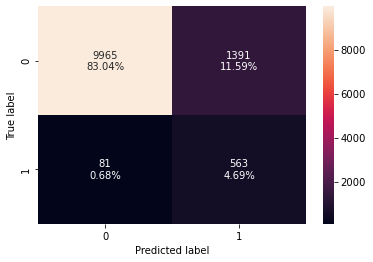

```python
confusion_matrix_sklearn(ab_classifier_under,X_val,y_val)
```

```python
ab_classifier_val_under_score =model_performance_classification_sklearn(
   ab_classifier_under, X_val,y_val
)

print("Training performance:")
ab_classifier_val_under_score
```

```
Training performance:
```

|  | Accuracy | Recall | Precision | F1 | Minimum_Vs_Model_cost |
| --- | --- | --- | --- | --- | --- |
| 0 | 0.877 | 0.874 | 0.288 | 0.433 | 0.518 |

### GradientBoostingClassifier-Undersampled

```python
gb_classifier_under = GradientBoostingClassifier(random_state=1)
gb_classifier_under.fit(X_train_un,y_train_un )
```

```
GradientBoostingClassifier(random_state=1)
```

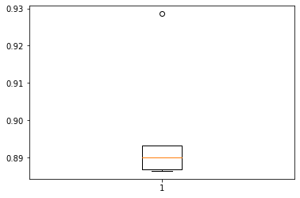

```python
scoring='recall'
kfold=StratifiedKFold(n_splits=5,shuffle=True,random_state=1)     #Setting number of splits equal to 5
cv_result_under=cross_val_score(estimator=gb_classifier_under, X=X_train_un, y=y_train_un, scoring=scoring, cv=kfold)
#Plotting boxplots for CV scores of model defined above
plt.boxplot(cv_result_under)
plt.show()
```

Performance on training set varies between 0.88 to 0.89 recall.

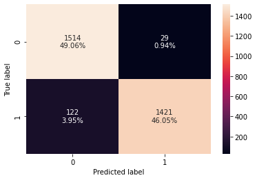

```python
confusion_matrix_sklearn(gb_classifier_under,X_train_un,y_train_un)
```

```python
gb_classifier_under_score =model_performance_classification_sklearn(
   gb_classifier_under, X_train_un,y_train_un
)

print("Training performance:")
gb_classifier_under_score
```

```
Training performance:
```

|  | Accuracy | Recall | Precision | F1 | Minimum_Vs_Model_cost |
| --- | --- | --- | --- | --- | --- |
| 0 | 0.951 | 0.921 | 0.980 | 0.950 | 0.879 |

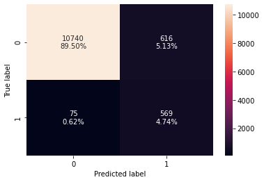

```python
confusion_matrix_sklearn(gb_classifier_under,X_val,y_val)
```

```python
gb_classifier_val_under_score =model_performance_classification_sklearn(
   gb_classifier_under,X_val,y_val
)

print("Training performance:")
gb_classifier_val_under_score
```

```
Training performance:
```

|  | Accuracy | Recall | Precision | F1 | Minimum_Vs_Model_cost |
| --- | --- | --- | --- | --- | --- |
| 0 | 0.942 | 0.884 | 0.480 | 0.622 | 0.661 |

data is overfitting

### XGBClassifier-Undersampled

```python
xgb_classifier_under = XGBClassifier(random_state=1,eval_metric='logloss')
xgb_classifier_under.fit( X_train_un,y_train_un )
```

```
XGBClassifier(base_score=0.5, booster='gbtree', colsample_bylevel=1,
              colsample_bynode=1, colsample_bytree=1, eval_metric='logloss',
              gamma=0, gpu_id=-1, importance_type='gain',
              interaction_constraints='', learning_rate=0.300000012,
              max_delta_step=0, max_depth=6, min_child_weight=1, missing=nan,
              monotone_constraints='()', n_estimators=100, n_jobs=8,
              num_parallel_tree=1, random_state=1, reg_alpha=0, reg_lambda=1,
              scale_pos_weight=1, subsample=1, tree_method='exact',
              validate_parameters=1, verbosity=None)
```

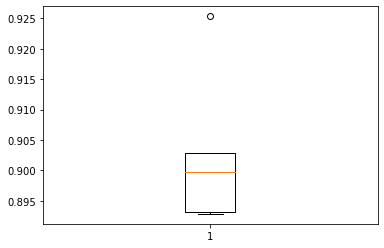

```python
scoring='recall'
kfold=StratifiedKFold(n_splits=5,shuffle=True,random_state=1)     #Setting number of splits equal to 5
cv_result_under=cross_val_score(estimator=xgb_classifier_under, X=X_train_un, y=y_train_un, scoring=scoring, cv=kfold)
#Plotting boxplots for CV scores of model defined above
plt.boxplot(cv_result_under)
plt.show()
```

Performance on training set varies between 0.89 to 0.90 recall.

```python
confusion_matrix_sklearn(xgb_classifier_under,X_train_un,y_train_un)
```

[output not shown]

```python
xgb_classifier_under_score =model_performance_classification_sklearn(
   xgb_classifier_under, X_train_un,y_train_un
)

print("Training performance:")
xgb_classifier_under_score
```

```
Training performance:
```

|  | Accuracy | Recall | Precision | F1 | Minimum_Vs_Model_cost |
| --- | --- | --- | --- | --- | --- |
| 0 | 1.000 | 1.000 | 1.000 | 1.000 | 1.000 |

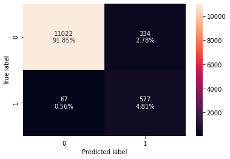

```python
confusion_matrix_sklearn(xgb_classifier_under,X_val,y_val)
```

```python
xgb_classifier_val_under_score =model_performance_classification_sklearn(
   xgb_classifier_under, X_val,y_val
)

print("Training performance:")
xgb_classifier_val_under_score
```

```
Training performance:
```

|  | Accuracy | Recall | Precision | F1 | Minimum_Vs_Model_cost |
| --- | --- | --- | --- | --- | --- |
| 0 | 0.967 | 0.896 | 0.633 | 0.742 | 0.743 |

data is overfitting

## Model Selection

```python
models_train_comp_df = pd.concat(
    [
        log_reg_model_train_perf.T,
        log_reg_model_val_perf.T,
        DecisionTree_train_perf.T,
        DecisionTree_val_perf.T,
        random_forest_train.T,
        random_forest_val .T,
        bagging_score.T,
        bagging_score_val.T,
        Adaboost_score.T,
        Adaboost_score_val.T,
        gb_classifier_score.T,
        gb_classifier_val.T,
        xgb_classifier_score.T,
        xgb_classifier_score_val.T,
        log_reg_over_score.T,
        log_reg_over_val_perf.T,
        DecisionTree_OVER_SCORE.T,
        DecisionTree_OVER_val_perf.T,
        rf_estimator_over_SCORE.T,
        rf_estimator_over_val_SCORE.T,
        bagging_classifier_over_SCORE.T,
        bagging_val_over_SCORE.T,
        ab_classifier_OVER_SCORE.T,
        ab_val_OVER_SCORE.T,
        gb_classifier_over_SCORE.T,
        gb_classifier_val_over_SCORE.T,
        xgb_classifier_over_SCORE.T,
        xgb_classifier_val_over_SCORE.T,
        log_reg_under_score.T,
        log_reg_val_under_score.T,
        DecisionTree_under_score.T,
        DecisionTree_val_under_score.T,
        rf_estimator_under_score.T,
        rf_estimator_val_under_score.T,
        bagging_classifier_under_score.T,
        bagging_classifier_val_under_score.T,
        ab_classifier_under_score.T,
        ab_classifier_val_under_score.T,
        gb_classifier_under_score.T,
        gb_classifier_val_under_score.T,
        xgb_classifier_under_score.T,
        xgb_classifier_val_under_score.T


    ],
    axis=1,
)
models_train_comp_df.columns = [
    "logestic regression on train",
    "logestic regression on val",
    "DecisionTree on train",
    "DecisionTree on val",
    "Random forest on train",
    "Random forest on val",
    "bagging classifier on train",
    "bagging classifier on val",
    "Adaboost classifier on train",
    "Adaboost classifier on val",
    "Gradient Boosting Classifier on train",
    "Gradient Boosting Classifier on val",
    "XGBoost Classifier on train ",
    "XGBoost Classifier on val",
    "logestic regression Oversampled on trian",
    "logestic regression Oversampled on val",
    "Decision Tree Oversampled on train ",
    "Decision Tree Oversampled on val",
    "Random Forest Oversampled on train ",
    "Random Forest Oversampled on val",
    "bagging classifier Oversampled on train",
    "bagging classifier Oversampled on val",
    "Adaboost classifier Oversampled on train",
    "Adaboost classifier Oversampled on val",
    "Gradient Boosting Oversampled on train",
    "Gradient Boosting Oversampled on val",
    "XGBoost Classifier Oversampled on train",
    "XGBoost Classifier Oversampled on val",
    "logestic regression Undersampled on train",
    "logestic regression Undersampled on val",
    "DecisionTree Undersampled on train",
    "DecisionTree Undersampled on val",
    "Random forest Undersampled on train ",
    "Random forest on Undersampled on val ",
    "bagging classifier Undersampled on train ",
    "bagging classifier Undersampled on val",
    "Adaboost classifier on Undersampled train ",
    "Adaboost classifier on Undersampled val ",
    "Gradient Boosting on Undersampled train",
    "Gradient Boosting on Undersampled val",
    "XGBoost Classifier on Undersampled trtain",
    "XGBoost Classifier on Undersampled val",
]
print("Training performance comparison:")
models_train_comp_df.T
```

```
Training performance comparison:
```

|  | Accuracy | Recall | Precision | F1 | Minimum_Vs_Model_cost |
| --- | --- | --- | --- | --- | --- |
| logestic regression on train | 0.971 | 0.524 | 0.898 | 0.662 | 0.552 |
| logestic regression on val | 0.973 | 0.545 | 0.909 | 0.682 | 0.563 |
| DecisionTree on train | 1.000 | 1.000 | 1.000 | 1.000 | 1.000 |
| DecisionTree on val | 0.969 | 0.745 | 0.701 | 0.722 | 0.653 |
| Random forest on train | 1.000 | 1.000 | 1.000 | 1.000 | 1.000 |
| Random forest on val | 0.988 | 0.781 | 0.992 | 0.874 | 0.732 |
| bagging classifier on train | 0.998 | 0.962 | 1.000 | 0.981 | 0.941 |
| bagging classifier on val | 0.985 | 0.745 | 0.968 | 0.842 | 0.698 |
| Adaboost classifier on train | 0.974 | 0.623 | 0.876 | 0.728 | 0.603 |
| Adaboost classifier on val | 0.974 | 0.610 | 0.869 | 0.717 | 0.595 |
| Gradient Boosting Classifier on train | 0.987 | 0.789 | 0.979 | 0.874 | 0.737 |
| Gradient Boosting Classifier on val | 0.984 | 0.744 | 0.947 | 0.833 | 0.694 |
| XGBoost Classifier on train | 1.000 | 1.000 | 1.000 | 1.000 | 1.000 |
| XGBoost Classifier on val | 0.990 | 0.831 | 0.978 | 0.898 | 0.776 |
| logestic regression Oversampled on trian | 0.880 | 0.875 | 0.884 | 0.879 | 0.802 |
| logestic regression Oversampled on val | 0.885 | 0.865 | 0.302 | 0.448 | 0.529 |
| Decision Tree Oversampled on train | 1.000 | 1.000 | 1.000 | 1.000 | 1.000 |
| Decision Tree Oversampled on val | 0.952 | 0.766 | 0.539 | 0.632 | 0.621 |
| Random Forest Oversampled on train | 1.000 | 1.000 | 1.000 | 1.000 | 1.000 |
| Random Forest Oversampled on val | 0.990 | 0.870 | 0.946 | 0.906 | 0.810 |
| bagging classifier Oversampled on train | 0.999 | 0.998 | 1.000 | 0.999 | 0.997 |
| bagging classifier Oversampled on val | 0.981 | 0.821 | 0.823 | 0.822 | 0.737 |
| Adaboost classifier Oversampled on train | 0.907 | 0.900 | 0.913 | 0.906 | 0.836 |
| Adaboost classifier Oversampled on val | 0.908 | 0.884 | 0.357 | 0.508 | 0.579 |
| Gradient Boosting Oversampled on train | 0.946 | 0.922 | 0.969 | 0.945 | 0.877 |
| Gradient Boosting Oversampled on val | 0.964 | 0.888 | 0.617 | 0.728 | 0.730 |
| XGBoost Classifier Oversampled on train | 0.999 | 0.999 | 1.000 | 0.999 | 0.998 |
| XGBoost Classifier Oversampled on val | 0.987 | 0.879 | 0.883 | 0.881 | 0.806 |
| logestic regression Undersampled on train | 0.873 | 0.863 | 0.285 | 0.428 | 0.513 |
| logestic regression Undersampled on val | 0.875 | 0.874 | 0.284 | 0.429 | 0.515 |
| DecisionTree Undersampled on train | 1.000 | 1.000 | 1.000 | 1.000 | 1.000 |
| DecisionTree Undersampled on val | 0.843 | 0.865 | 0.237 | 0.372 | 0.464 |
| Random forest Undersampled on train | 1.000 | 1.000 | 1.000 | 1.000 | 1.000 |
| Random forest on Undersampled on val | 0.960 | 0.901 | 0.579 | 0.705 | 0.723 |
| bagging classifier Undersampled on train | 0.990 | 0.981 | 0.999 | 0.990 | 0.968 |
| bagging classifier Undersampled on val | 0.945 | 0.877 | 0.494 | 0.632 | 0.665 |
| Adaboost classifier on Undersampled train | 0.902 | 0.887 | 0.916 | 0.901 | 0.822 |
| Adaboost classifier on Undersampled val | 0.877 | 0.874 | 0.288 | 0.433 | 0.518 |
| Gradient Boosting on Undersampled train | 0.951 | 0.921 | 0.980 | 0.950 | 0.879 |
| Gradient Boosting on Undersampled val | 0.942 | 0.884 | 0.480 | 0.622 | 0.661 |
| XGBoost Classifier on Undersampled trtain | 1.000 | 1.000 | 1.000 | 1.000 | 1.000 |
| XGBoost Classifier on Undersampled val | 0.967 | 0.896 | 0.633 | 0.742 | 0.743 |

- `XGBoost Classifier`, `Random Forest Oversampled data` and `XGBoost Classifier Oversampled data` are my chosen models because all scores are good and acceptable in train and validation data especially recall and Minimum_Vs_Model_cost.

## HyperparameterTuning

- **Hyperparameter tuning can take a long time to run, so to avoid that time complexity - you can use the following grids, wherever required.**

#### For XGBoost:

param_grid={'n_estimators':np.arange(150,300,50),'scale_pos_weight':[5,10], 'learning_rate':[0.1,0.2], 'gamma':[0,3,5], 'subsample':[0.8,0.9]}

#### For Gradient Boosting:

param_grid = { "init": [AdaBoostClassifier(random_state=1),DecisionTreeClassifier(random_state=1)], "n_estimators": np.arange(75,150,25), "learning_rate": [0.2, 0.05, 1], "subsample":[0.5,0.7], "max_features":[0.5,0.7]}

#### For Adaboost:

param_grid = { "n_estimators": np.arange(10, 110, 20), "learning_rate": [ 0.2, 0.05, 1], "base_estimator": [ DecisionTreeClassifier(max_depth=1, random_state=1), DecisionTreeClassifier(max_depth=2, random_state=1), DecisionTreeClassifier(max_depth=3, random_state=1)]}

#### For logistic Regression:

param_grid = {'C': np.arange(0.1,1.1,0.1)}

#### For Bagging Classifier:

param_grid = { 'max_samples': [0.8,0.9], 'max_features': [0.8,0.9], 'n_estimators' : [40,50]}

#### For Random Forest:

param_grid = { "n_estimators": [150,250], "min_samples_leaf": np.arange(1, 3), "max_features": ['sqrt','log2'], "max_samples": np.arange(0.2, 0.6, 0.1)}

#### For Decision Trees:

param_grid = {'max_depth': np.arange(2,20), 'min_samples_leaf': [1, 2, 5, 7], 'max_leaf_nodes' : [5, 10,15], 'min_impurity_decrease': [0.0001,0.001] }

### tuning of XGBClassifier

```python
%%time
from sklearn.pipeline import Pipeline
#Creating pipeline
pipe=Pipeline([
   # ('scaler', StandardScaler() ),
    ('XGBClassifier', XGBClassifier(random_state=1,eval_metric='logloss') )
])

#Parameter grid to pass in GridSearchCV
param_grid={'XGBClassifier__n_estimators': np.arange(150,300,50),
            'XGBClassifier__scale_pos_weight':[5,10],
            'XGBClassifier__learning_rate':[0.1,0.2],
            'XGBClassifier__gamma':[0,3,5],
            'XGBClassifier__subsample':[0.9]}

# scorer = metrics.make_scorer(metrics.recall_score)

#Calling GridSearchCV
grid_cv = GridSearchCV(estimator=pipe, param_grid=param_grid, scoring=scorer, cv=5, n_jobs = -1)

#Fitting parameters in GridSeachCV
grid_cv.fit(X_train,y_train)


print("Best parameters are {} with CV score={}:" .format(grid_cv.best_params_,grid_cv.best_score_))
```

```
Best parameters are {'XGBClassifier__gamma': 5, 'XGBClassifier__learning_rate': 0.1, 'XGBClassifier__n_estimators': 200, 'XGBClassifier__scale_pos_weight': 10, 'XGBClassifier__subsample': 0.9} with CV score=0.8000345995827542:
Wall time: 37min 7s
```

```python
xgb_tuned2 = XGBClassifier(
    random_state=1,
    n_estimators=200,
    scale_pos_weight=10,
    gamma=5,
    subsample=0.9,
    learning_rate=0.1,
    eval_metric="logloss",

)
# Fit the model on training data
xgb_tuned2.fit(X_train, y_train)
```

```
XGBClassifier(base_score=0.5, booster='gbtree', colsample_bylevel=1,
              colsample_bynode=1, colsample_bytree=1, eval_metric='logloss',
              gamma=5, gpu_id=-1, importance_type='gain',
              interaction_constraints='', learning_rate=0.1, max_delta_step=0,
              max_depth=6, min_child_weight=1, missing=nan,
              monotone_constraints='()', n_estimators=200, n_jobs=8,
              num_parallel_tree=1, random_state=1, reg_alpha=0, reg_lambda=1,
              scale_pos_weight=10, subsample=0.9, tree_method='exact',
              validate_parameters=1, verbosity=None)
```

```python
# Calculating different metrics on train set
xgboost_random_train = model_performance_classification_sklearn(
    grid_cv, X_train, y_train
)
print("Training performance:")
xgboost_random_train
```

```
Training performance:
```

|  | Accuracy | Recall | Precision | F1 | Minimum_Vs_Model_cost |
| --- | --- | --- | --- | --- | --- |
| 0 | 0.999 | 1.000 | 0.985 | 0.993 | 0.995 |

```python
# Calculating different metrics on validation set
xgboost_random_val= model_performance_classification_sklearn(
    grid_cv, X_val, y_val
)
print("Training performance:")
xgboost_random_val
```

```
Training performance:
```

|  | Accuracy | Recall | Precision | F1 | Minimum_Vs_Model_cost |
| --- | --- | --- | --- | --- | --- |
| 0 | 0.990 | 0.870 | 0.946 | 0.906 | 0.810 |

the model peformance on both train and validation data are good

### tuning of Randomfarest classifier

```python
# Choose the type of classifier.
rf_tuned = RandomForestClassifier(random_state=1)

parameters = { "n_estimators": [150,250],
              "min_samples_leaf": np.arange(1, 3),
              "max_features": ['sqrt','log2'],
              "max_samples": np.arange(0.2, 0.6, 0.1)}


# Run the grid search
grid_obj = GridSearchCV(rf_tuned, parameters, scoring=scorer,cv=5,n_jobs=-1)
grid_obj = grid_obj.fit(X_train_over, y_train_over)

# Set the clf to the best combination of parameters
rf_tuned = grid_obj.best_estimator_

# Fit the best algorithm to the data.
rf_tuned.fit(X_train_over, y_train_over)
```

```
RandomForestClassifier(max_features='sqrt', max_samples=0.5000000000000001,
                       n_estimators=250, random_state=1)
```

```python
# Calculating different metrics on train set
rf_tuned_train = model_performance_classification_sklearn(
    rf_tuned, X_train_over, y_train_over
)
print("Training performance:")
rf_tuned_train
```

```
Training performance:
```

|  | Accuracy | Recall | Precision | F1 | Minimum_Vs_Model_cost |
| --- | --- | --- | --- | --- | --- |
| 0 | 0.999 | 0.998 | 1.000 | 0.999 | 0.996 |

```python
# Calculating different metrics on train set
rf_tuned_val = model_performance_classification_sklearn(
    rf_tuned, X_val, y_val
)
print("Training performance:")
rf_tuned_val
```

```
Training performance:
```

|  | Accuracy | Recall | Precision | F1 | Minimum_Vs_Model_cost |
| --- | --- | --- | --- | --- | --- |
| 0 | 0.989 | 0.879 | 0.917 | 0.898 | 0.814 |

performance of RandomForestClassifier model is good on train and validation data

### XGBClassifier Oversampled tuning

```python
%%time
from sklearn.pipeline import Pipeline
#Creating pipeline
pipe=Pipeline([

    ('XGBClassifier', XGBClassifier(random_state=1,eval_metric='logloss') )
])

#Parameter grid to pass in GridSearchCV
param_grid={'XGBClassifier__n_estimators': np.arange(150,300,50),
            'XGBClassifier__scale_pos_weight':[5,10],
            'XGBClassifier__learning_rate':[0.1,0.2],
            'XGBClassifier__gamma':[0,3,5],
            'XGBClassifier__subsample':[0.9]}

# Type of scoring used to compare parameter combinations
# scorer = metrics.make_scorer(metrics.recall_score)

#Calling GridSearchCV
grid_cv2 = GridSearchCV(estimator=pipe, param_grid=param_grid, scoring=scorer, cv=5, n_jobs = -1)

#Fitting parameters in GridSeachCV
grid_cv2.fit(X_train_over, y_train_over)


print("Best parameters are {} with CV score={}:" .format(grid_cv2.best_params_,grid_cv2.best_score_))
```

```
Best parameters are {'XGBClassifier__gamma': 0, 'XGBClassifier__learning_rate': 0.2, 'XGBClassifier__n_estimators': 250, 'XGBClassifier__scale_pos_weight': 10, 'XGBClassifier__subsample': 0.9} with CV score=0.9887514609860949:
Wall time: 1h 11min 40s
```

```python
# Calculating different metrics on train set
xgboost_over_train = model_performance_classification_sklearn(
    grid_cv2, X_train_over, y_train_over
)
print("Training performance:")
xgboost_over_train
```

```
Training performance:
```

|  | Accuracy | Recall | Precision | F1 | Minimum_Vs_Model_cost |
| --- | --- | --- | --- | --- | --- |
| 0 | 1.000 | 1.000 | 1.000 | 1.000 | 1.000 |

```python
# Calculating different metrics on train set
xgboost_over_val = model_performance_classification_sklearn(
    grid_cv2, X_val, y_val
)
print("Training performance:")
xgboost_over_val
```

```
Training performance:
```

|  | Accuracy | Recall | Precision | F1 | Minimum_Vs_Model_cost |
| --- | --- | --- | --- | --- | --- |
| 0 | 0.985 | 0.890 | 0.843 | 0.866 | 0.807 |

## Model Performance comparison and choosing the final model

```python
models_train_tuned_df = pd.concat([
        xgboost_random_train.T,
        xgboost_random_val.T,
        rf_tuned_val.T,
        rf_tuned_train.T,
        xgboost_over_val.T,
        xgboost_over_train.T
    ],
axis=1
)
models_train_tuned_df.columns = [

    "XGBoost Classifier_tuned on train",
    "XGBoost Classifier_tuned on val",
    "Random Forest_tuned Oversampled on val",
    "Random Forest_tuned Oversampled on train",
    "XGBoost Classifier_tuned Oversampled on val",
    "XGBoost Classifier_tuned Oversampled on train",
]
print("Training performance comparison:")
models_train_tuned_df.T
```

```
Training performance comparison:
```

|  | Accuracy | Recall | Precision | F1 | Minimum_Vs_Model_cost |
| --- | --- | --- | --- | --- | --- |
| XGBoost Classifier_tuned on train | 0.999 | 1.000 | 0.985 | 0.993 | 0.995 |
| XGBoost Classifier_tuned on val | 0.990 | 0.870 | 0.946 | 0.906 | 0.810 |
| Random Forest_tuned Oversampled on val | 0.989 | 0.879 | 0.917 | 0.898 | 0.814 |
| Random Forest_tuned Oversampled on train | 0.999 | 0.998 | 1.000 | 0.999 | 0.996 |
| XGBoost Classifier_tuned Oversampled on val | 0.985 | 0.890 | 0.843 | 0.866 | 0.807 |
| XGBoost Classifier_tuned Oversampled on train | 1.000 | 1.000 | 1.000 | 1.000 | 1.000 |

Between all three tuned model I choose XGBoost Classifier_tuned.

The scores are all good but I think `XGBoost Classifier_tuned Oversampled` has overfitting.

## Test set final performance

```python
data2 = pd.read_csv('Test.csv')
```

```python
data2.info()
```

```
<class 'pandas.core.frame.DataFrame'>
RangeIndex: 10000 entries, 0 to 9999
Data columns (total 41 columns):
 #   Column  Non-Null Count  Dtype
---  ------  --------------  -----
 0   V1      9989 non-null   float64
 1   V2      9993 non-null   float64
 2   V3      10000 non-null  float64
 3   V4      10000 non-null  float64
 4   V5      10000 non-null  float64
 5   V6      10000 non-null  float64
 6   V7      10000 non-null  float64
 7   V8      10000 non-null  float64
 8   V9      10000 non-null  float64
 9   V10     10000 non-null  float64
```

[output cut: 33 more lines]

Just tack a look at test data

- we have some missing values here in v1 and v2
- all columns type are like train data

```python
data2.duplicated().sum()# we have no duplicant value
```

```
0
```

```python
X_test = data2.drop(['Target'],axis=1)#defenition of X and Y
Y_test= data2['Target']
X_test = pd.DataFrame(imputer.transform(X_test),columns=X_test.columns)#Replacing missing values with median. just like train data
```

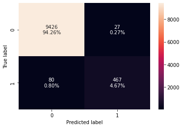

```python
confusion_matrix_sklearn(grid_cv, X_test, Y_test)
```

```python
xgb_classifier_score =model_performance_classification_sklearn(
    grid_cv, X_test, Y_test
)

print("Testing performance:")
xgb_classifier_score
```

```
Testing performance:
```

|  | Accuracy | Recall | Precision | F1 | Minimum_Vs_Model_cost |
| --- | --- | --- | --- | --- | --- |
| 0 | 0.989 | 0.854 | 0.945 | 0.897 | 0.794 |

it seems that performance of our final model on test data is good. metric of Minimum_Vs_Model_cost is acceptable(0.79).

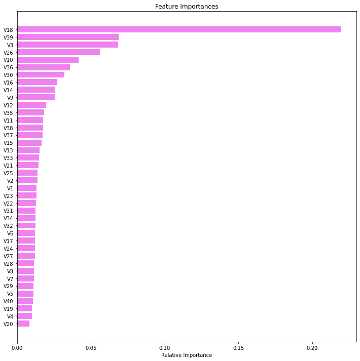

```python
feature_names = X_test.columns
importances =xgb_tuned2.feature_importances_
indices = np.argsort(importances)

plt.figure(figsize=(12, 12))
plt.title("Feature Importances")
plt.barh(range(len(indices)), importances[indices], color="violet", align="center")
plt.yticks(range(len(indices)), [feature_names[i] for i in indices])
plt.xlabel("Relative Importance")
plt.show()
```

- V18 is the most important variable in predicting maintenance followed by V39, V3, V26 and V10.

## Pipelines to build the final model

```python
# Splitting the data into train and test sets
X_train, X_test, y_train, y_test = train_test_split(
    X, Y, test_size=0.30, random_state=1, stratify=Y
)
print(X_train.shape, X_test.shape)
```

```
(28000, 40) (12000, 40)
```

```python
# Creating new pipeline with best parameters
model = Pipeline(
    steps=[
        (
            "XGB",
            XGBClassifier(
                eval_metric='logloss',
                gamma=5,
                learning_rate=0.1,
                n_estimators=150,
                random_state=1,
                scale_pos_weight=10,
                subsample=0.9,
            ),
        ),
    ]
)
# Fit the model on training data
model.fit(X_train, y_train)
```

```
Pipeline(steps=[('XGB',
                 XGBClassifier(base_score=0.5, booster='gbtree',
                               colsample_bylevel=1, colsample_bynode=1,
                               colsample_bytree=1, eval_metric='logloss',
                               gamma=5, gpu_id=-1, importance_type='gain',
                               interaction_constraints='', learning_rate=0.1,
                               max_delta_step=0, max_depth=6,
                               min_child_weight=1, missing=nan,
                               monotone_constraints='()', n_estimators=150,
                               n_jobs=8, num_parallel_tree=1, random_state=1,
                               reg_alpha=0, reg_lambda=1, scale_pos_weight=10,
                               subsample=0.9, tree_method='exact',
                               validate_parameters=1, verbosity=None))])
```

# Business Insights and Conclusions

- We have been able to build a predictive model:

  a) that the ReneWind company can deploy this model to identify generator's failures so that the generator could be repaired before failing/breaking and the overall maintenance cost of the generators can be brought down.

  b) that the ReneWing company can use to find the key causes that drive maintenance.

  c) based on which companies can take appropriate actions to build better retention policies maintenance costs.
- Factors that drive the maintenance - V18, V39,V3,V26 and V10
- The model can maximize the ratio of minimum possible maintenance cost and the maintenance cost associated with the model (Minimum_Vs_Model_cost) = 0.79